# ggplot2_solutions_chapter5

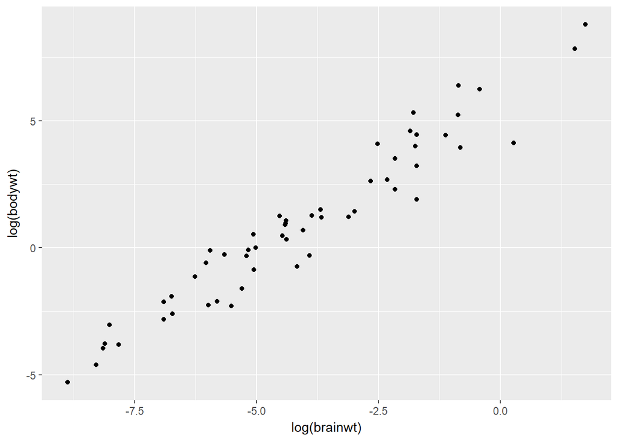

```r
ggplot(aes(log(brainwt), log(bodywt)), data = msleep) + geom_point()
```

*Question 2* What does the following code do? Does it work? Does it make sense? Why/why not?

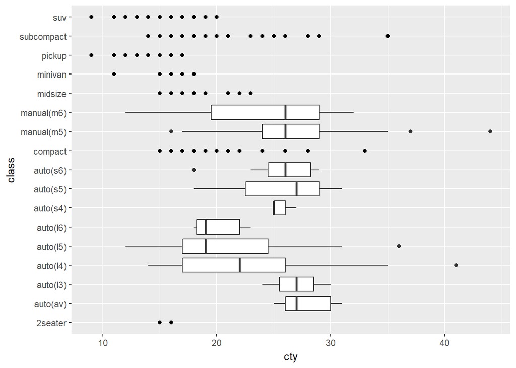

```r
ggplot(mpg) + geom_point(aes(class, cty)) + geom_boxplot(aes(trans, hwy)) + coord_flip()
```

This plot is using mpg dataset as a blank background without setting aesthetics. Then it adds the first layer using scatterplot with class as x-axis and cty on y axis. After that, it adds another layer using boxplot with trans on x-axis and hwy on y-axis.

It doesn’t work because the x-axis: 1. too crowded, need to add coord_flip() to read all the class and trans labels. 2. Trans and class are mixed together, it doesn’t make sense. Also, boxplot is mixed with scatterplot. Y-axis has two different value groups, the hwy and the cty. These two contain both continuous values but are different in nature because one is city miles per gallon, the other is highway miles per gallon. In the end, the x-axis and y-axis labels only have class and cty, it doesn’t label trans and hwy.

*Question 3* What happens if you try to use a continuous variable on the x axis in one layer, and a categorical variable in another layer? What happens if you do it in the opposite order?

```r
ggplot(mpg) +
  geom_point(aes(hwy, cyl)) +
  geom_point(aes(drv, cty))
```

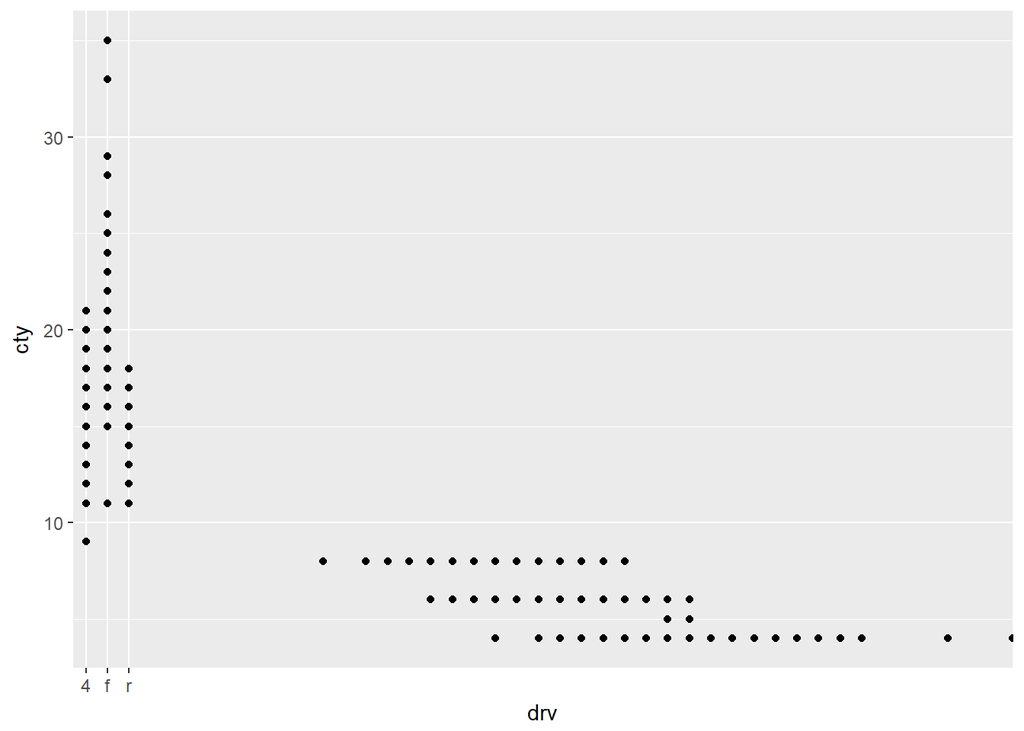

```r
ggplot(mpg) +
  geom_point(aes(drv, cty)) +
  geom_point(aes(hwy, cyl))
```

If you set first x-axis with categorical values, and then with continuous values, the plot will run but the result doesn’t make sense at all. However, if you do it the opposite way, R will report errors.

## *Exercises 5.5.1*

*Question 1* Download and print out the ggplot2 cheatsheet from http://www.rstudio. com/resources/cheatsheets/ so you have a handy visual reference for all the geoms.

Easy to do, just download.

*Question 2* Look at the documentation for the graphical primitive geoms. Which aesthetics do they use? How can you summarise them in a compact form?

geom_primitives such as geom_point(), geom_path(), geom_rect(), geom_polyon(), geom_text() and so on all have common aesthetics such as: x, y, color, alpha, fill, group, size. Other features such as geom_point()’s stroke, or geom_path() and geom_rect()’s linetype, belong to these funtions themselves. But the common ones are available in each function.

*Question 3* What’s the best way to master an unfamiliar geom? List three resources to help you get started.

You can use Winston Chang’s R Graphics Cookbook, which shows you the recipe for different types of plots. Or you could use Hadley Wickham’s gplot2 Elegant Graphics for Data Analysis. Or you can just use ?function to read the R documentation with examples to learn.

*Question 4* For each of the plots below, identify the geom used to draw it. The first one on the upper left is violin

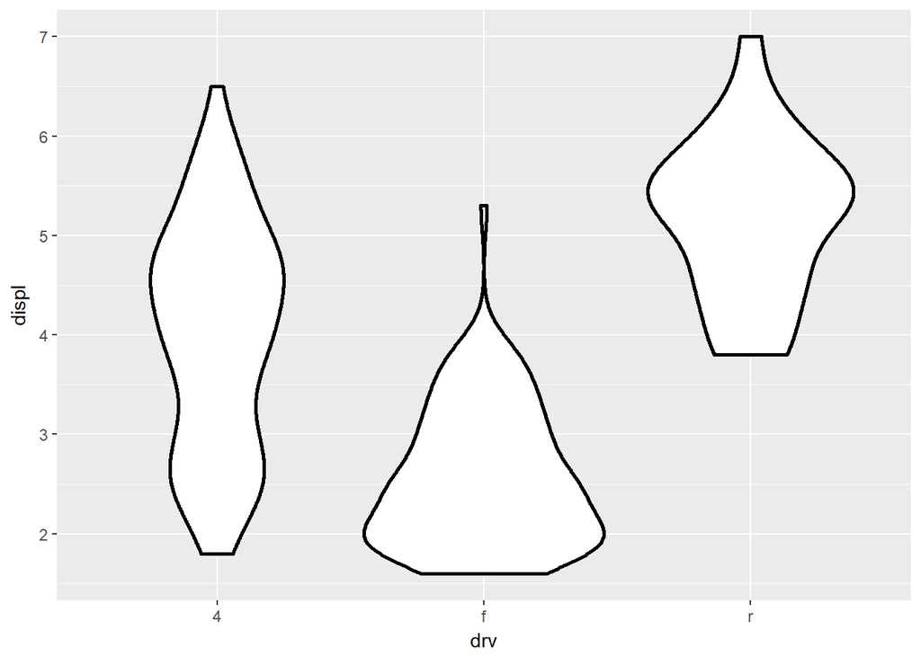

```r
ggplot(mpg, aes(drv, displ)) +
  geom_violin(size = 1, color = "black")
```

The one on upper right is a jitter plot with size and alpha features. It is not geom_point() because this results in overplotting.

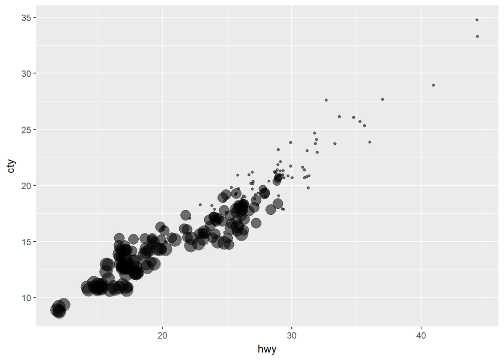

```r
ggplot(mpg) +
  geom_jitter(aes(x = hwy, y = cty, alpha = 0.1, size = cyl)) +
  theme(legend.position = "none")
```

The middle left plot is a hexagonal plot

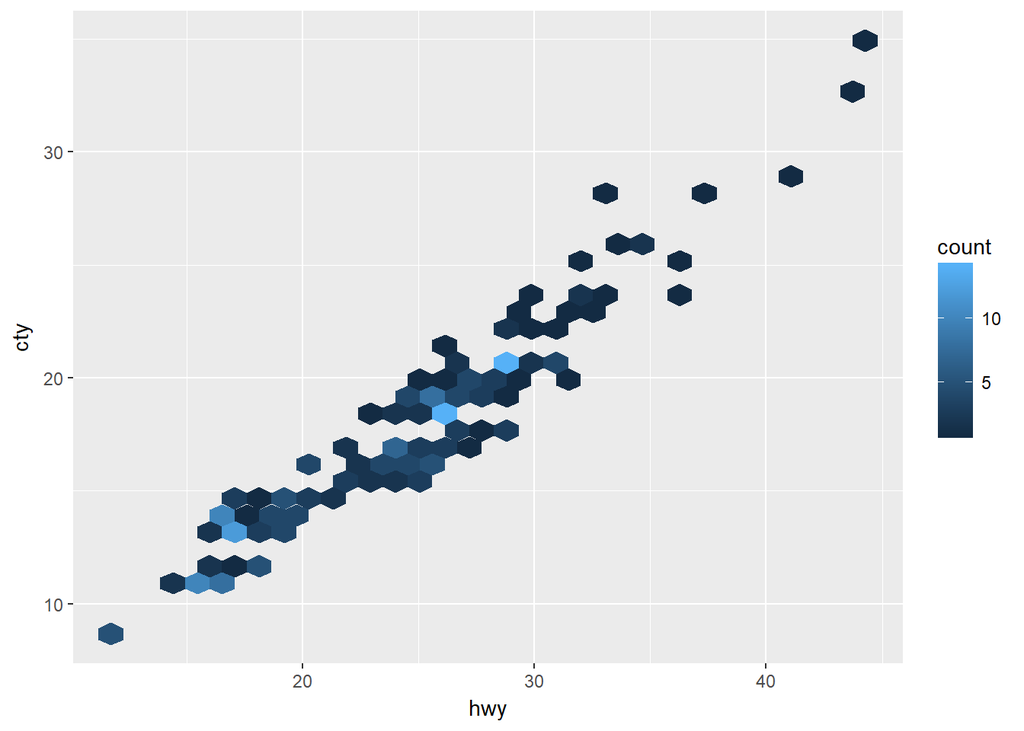

```r
ggplot(mpg) +
  geom_hex(aes(x = hwy, y = cty))
```

Middle right is a jitter plot, thanks to stack overflow user PoGibas for the help. PoGibas mentioned: “By default jitter in geom_jitter is too large and we need to specify our own height and width of jitter by using position_jitter function.”"

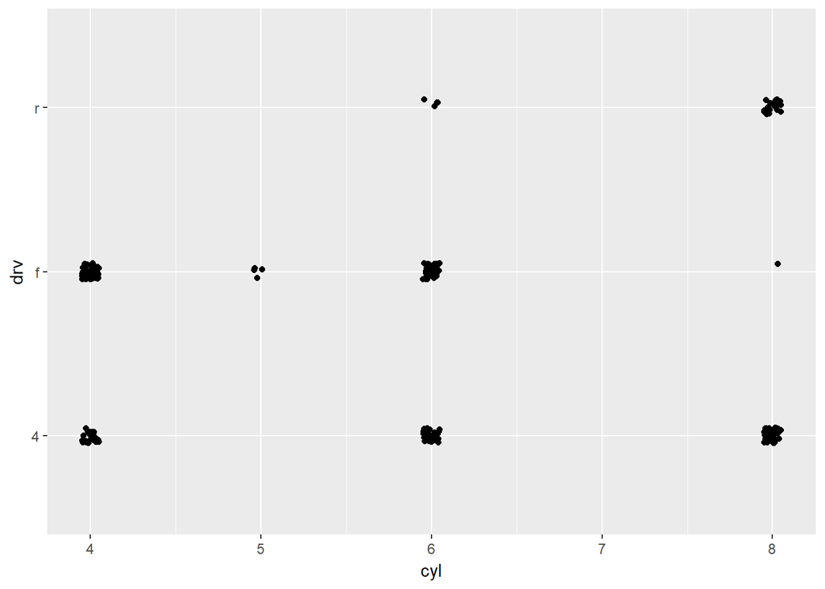

```r
ggplot(mpg, aes(x = cyl, y = drv)) +
  geom_jitter(width = 0.05, height = 0.05)
```

```r
# or geom_jitter(position = position_jitter(0.05, 0.05))
```

Next, we have to use the economics package in ggplot2.

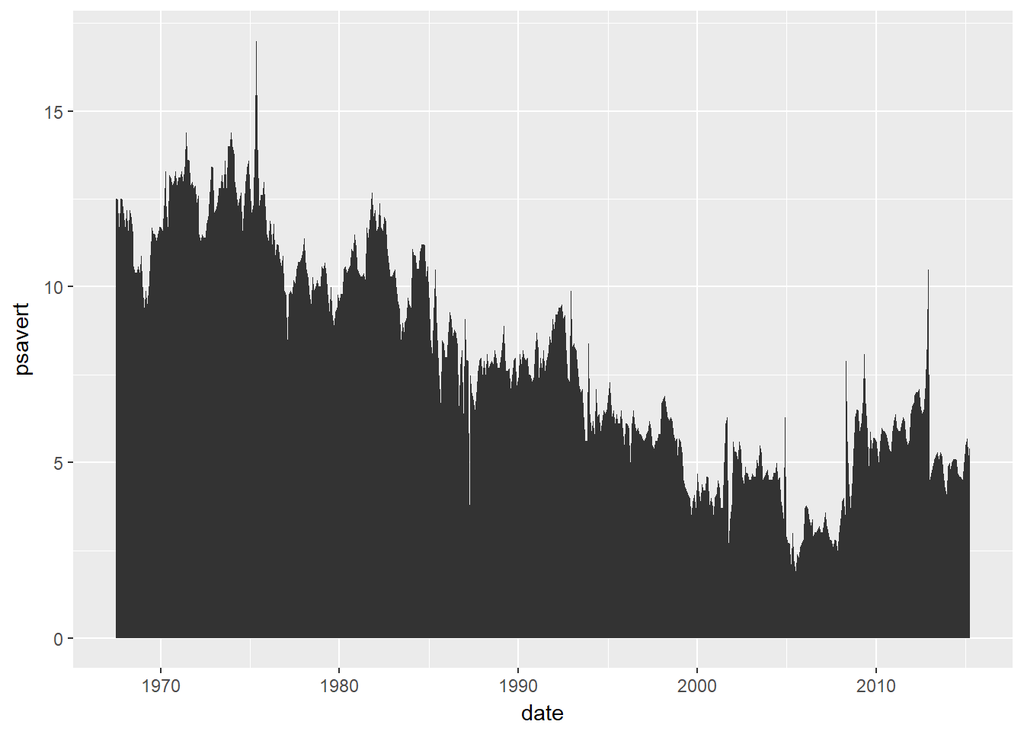

```r
ggplot(economics, aes(date, psavert)) +
  geom_area()
```

Finally, the last plot.

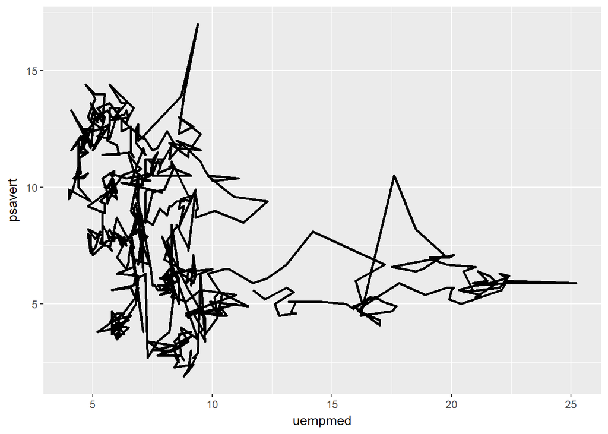

```r
ggplot(economics, aes(uempmed, psavert)) +
  geom_path(size = 1)
```

*Question 5* For each of the following problems, suggest a useful geom: -Display how a variable has changed over time. geom_line() -Show the detailed distribution of a single variable. geom_histogram() -Focus attention on the overall trend in a large dataset. geom_line(), geom_area() -Draw a map. geom_sf(), geom_polygon(), coord_quickmap()  
-Label outlying points. geom_point(), geom_text()

## *Exercises 5.6.2*

*Question 1* The code below creates a similar dataset to stat smooth(). Use the appropriate geoms to mimic the default geom smooth() display.

```r
mod <- loess(hwy ~ displ, data = mpg)
smoothed <- data.frame(displ = seq(1.6, 7, length = 50))
pred <- predict(mod, newdata = smoothed, se = TRUE)
smoothed$hwy <- pred$fit
smoothed$hwy_lwr <- pred$fit - 1.96 * pred$se.fit
smoothed$hwy_upr <- pred$fit + 1.96 * pred$se.fit
smoothed
```

```
##       displ      hwy  hwy_lwr  hwy_upr
## 1  1.600000 33.09286 31.55842 34.62729
## 2  1.710204 32.16100 30.90050 33.42149
## 3  1.820408 31.26635 30.23415 32.29855
## 4  1.930612 30.41403 29.55725 31.27081
## 5  2.040816 29.60168 28.86378 30.33957
## 6  2.151020 28.82979 28.15456 29.50502
## 7  2.261224 28.09612 27.43616 28.75608
## 8  2.371429 27.39752 26.72080 28.07424
## 9  2.481633 26.73611 26.02849 27.44372
## 10 2.591837 26.11707 25.37791 26.85622
## 11 2.702041 25.52830 24.76057 26.29604
## 12 2.812245 24.99810 24.20934 25.78686
## 13 2.922449 24.53340 23.71434 25.35245
## 14 3.032653 24.09418 23.23668 24.95168
```

[output cut: 36 more lines]

We need to use geom_ribbon() instead of geom_area(), though area sounds more like coloring the region between the two standard deviation values. geom_ribbon() and geom_area() both display a y interval for given x values. However, geom_are() is a special case of geom_ribbon() for geom_area()’s ymin is fixed at 0.

The sequence of the layers, without knowing other functions to deal with it, is important. If we plot the geom_ribbon() in the end filled with color, it will shadow the smooth line and data points.

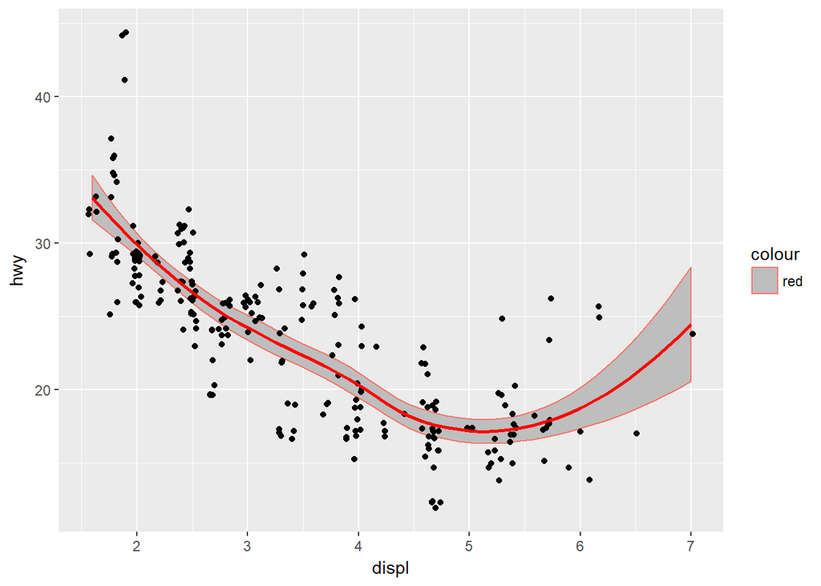

```r
ggplot(mpg, aes(displ, hwy)) +
  geom_ribbon(data = smoothed, aes(ymin = hwy_lwr, ymax = hwy_upr, color = "red"), fill = "grey") +
  geom_point(position = "jitter") +
  geom_line(data = smoothed, aes(y = hwy), size = 1, color = "red")
```

*Question 2* What stats were used to create the following plots? Not quite sure about this one.

*Question 3* Read the help for stat sum() then use geom count() to create a plot that shows the proportion of cars that have each combination of drv and trans.

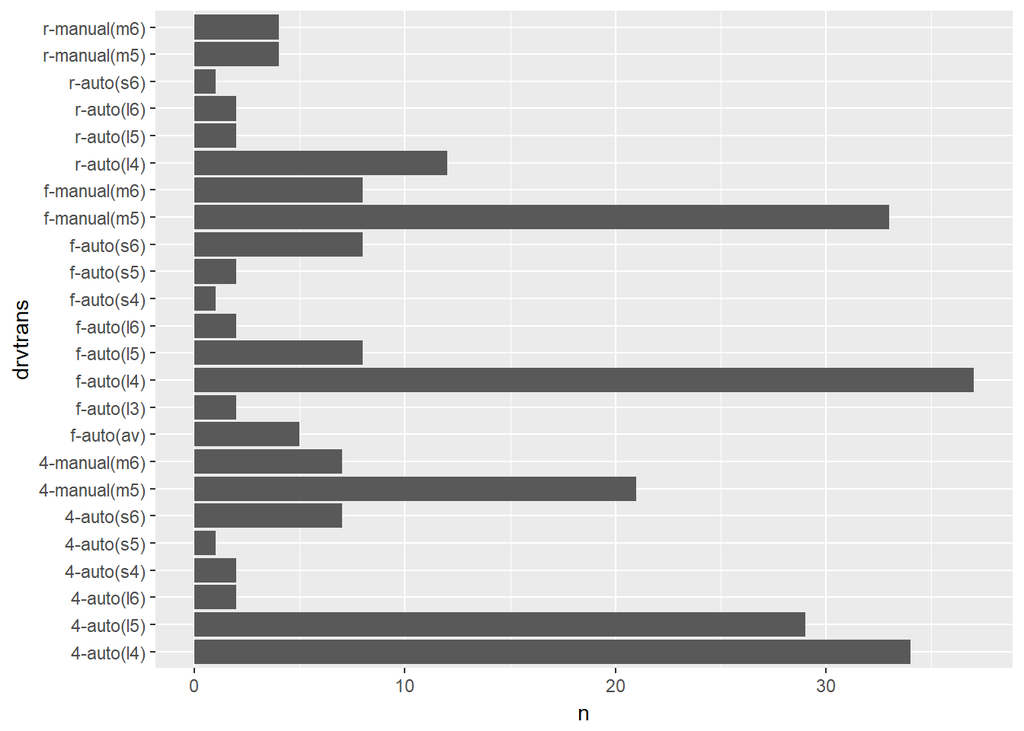

```r
mpg %>%
  group_by(drv, trans) %>%
  summarise(n = n()) %>%
  mutate(drvtrans = paste0(drv, "-", trans)) %>%
  ggplot() +
  geom_bar(aes(drvtrans, n), stat = "identity") +
  coord_flip()
```

## *Exercises 5.7.1*

*Question 1* When might you use position nudge()? Read the documentation.

position_nudge is generally useful for adjusting the position of items on discrete scales by a small amount. Nudging is built in to geom_text because it’s so useful for moving labels a small distance from what they’re labelling.

e.g.:

```r
ggplot(df, aes(x, y)) +
  geom_point() +
  geom_text(aes(label = y), position = position_nudge(y = -0.1))
```

*Question 2* Many position adjustments can only be used with a few geoms. For example, you can’t stack boxplots or errors bars. Why not? What properties must a geom possess in order to be stackable? What properties must it possess to be dodgeable?

Not sure.

*Question 3* Why might you use geom jitter() instead of geom count()? What are the advantages and disadvantages of each technique?

Count() counts the number of obervations at each given x values, and then map the point. The more observation one given x value has, the larger the point.

Jitter() adds random noise and shows how the observations are distributed in the plot.

*Question 4* When might you use a stacked area plot? What are the advantages and disadvantages compared to a line plot?

When you want to separate the x values based on a given category, you use stacked area plot. Advantage is it allows you to show the difference based on the criteria, but sometimes it is hard to figure out the real magnitude.